# Принятие решений в бизнесе

Вы — аналитик крупного интернет-магазина. Вместе с отделом маркетинга вы подготовили список гипотез для увеличения выручки. Приоритизируйте гипотезы, запустите A/B-тест и проанализируйте результаты.

Цель исследования: приоритизировать гипотезы, после проведения А/В-теста проанализировать его результаты и принять решение о продолжении или прекращении теста, интерпритировать результаты теста.

Ход исследования:

1. Приритизировать гипотезы:

   1.1. Загрузить данные.

   1.2. Применить фреймворк ICE для приоритизации гипотез. Отсортировать их по убыванию приоритета.

   1.3. Применить фреймворк RICE для приоритизации гипотез. Отсортировать их по убыванию приоритета.

   1.4. Указать, как изменилась приоритизация гипотез при применении RICE вместо ICE. Объяснить, почему так произошло.
2. Проанализировать A/B-тест:

   2.1. Загрузить данные.

   2.2. Создать массив уникальных пар значений дат и групп теста в датафрейме dates_groups.

   2.3. Собрать агрегированные кумулятивные по дням данные о заказх в датафрейме orders_aggregated.

   2.4. Собрать агрегированные кумулятивные по дням данные о посетителях сайта в датафрейме visitors_aggregated.

   2.5. Объединить таблицы с кумулятивными данными в датафрейме cumulative_data.

   2.6. Создать таблицы с кумулятивным количеством заказов и кумулятивной выручкой по дням в разных группах cumulative_revenue_a и cumulative_revenue_b.

   2.7. Построить график кумулятивной выручки по группам и сделать по нему вывод.

   2.8. Построить график кумулятивного среднего чека по группам и сделать по нему вывод.

   2.9. Построить график относительного изменения кумулятивного среднего чека группы B к группе A и сделать по нему вывод.

   2.10. Посчитать среднее количество заказов на посетителя в столбце conversion датафрейма cumulative_data.

   2.11. Разделить кумулятивные по дням данные по группам в датафреймах cumulative_data_a и cumulative_data_b.

   2.12. Построить график кумулятивного среднего количества заказов на посетителя по группам и сделать по нему вывод.

   2.13. Построить график изменения кумулятивного среднего количества заказов на посетителя группы B к группе A и сделать по нему вывод.

   2.14. Построить точечную диаграмму числа заказов на одного пользователя.

   2.15. Посчитать выборочные перцентили количества заказов на одного пользователя, сделать вывод и определить границу для определения аномальных пользователей.

   2.16. Построить точечную диаграмму стоимости заказов.

   2.17. Посчитать выборочные перцентили стоимости заказов, сделать вывод и определить границу для определения аномальных заказов.

   2.18. Посчитать статистическую значимость различий в среднем числе заказов на посетителя между группами без удаления аномальных пользователей и сделать вывод.

   2.19. Посчитать статистическую значимость различия в среднем чеке заказа между группами без удаления аномальных пользователей и сделать вывод.

   2.20. Посчитать статистическую значимость различий в среднем количестве заказов на посетителя между группами по «очищенным» данным и сделать вывод.

   2.21. Посчитать статистическую значимость различий в среднем чеке заказа между группами по «очищенным» данным и сделать вывод.

   2.22. Сравнить графики до и после удаления аномальных пользователей.

   2.23. Принять решение по результату теста и объяснить его.

Импорт библиотек и функций:

```python
from scipy import stats as st
import pandas as pd
import matplotlib.pyplot as plt
import numpy as np
import datetime as dt
```

```python
def load(df):
        print ('Первые 10 строк таблицы:')
        print ()
        display (df.head(10))
        print ()
        print ('Иноформация о таблице:')
        print ()
        display (df.info())
        print ()
        print ('Количество дубликатов в таблице:')
        print ()
        display (df.duplicated().sum())
        print ()
        print ('Количество пропусков в таблице:')
        print ()
        display (df.isna().sum())
        print ()
        print ('Процентное соотношение пропусков к общему числу значений для каждого столбца')
        print ()
        display (pd.DataFrame(round(df.isna().mean()*100,)).style.background_gradient('coolwarm'))
```

```python
pd.set_option('display.max_columns', None)
```

```python
pd.set_option('display.max_colwidth', None)
```

## Приоритизация гипотез.

### Загрузим данные:

```python
hypothesis = pd.read_csv('/datasets/hypothesis.csv')
```

```python
load(hypothesis)
```

```
Первые 10 строк таблицы:
```

|  | Hypothesis | Reach | Impact | Confidence | Efforts |
| --- | --- | --- | --- | --- | --- |
| 0 | Добавить два новых канала привлечения трафика, что позволит привлекать на 30% больше пользователей | 3 | 10 | 8 | 6 |
| 1 | Запустить собственную службу доставки, что сократит срок доставки заказов | 2 | 5 | 4 | 10 |
| 2 | Добавить блоки рекомендаций товаров на сайт интернет магазина, чтобы повысить конверсию и средний чек заказа | 8 | 3 | 7 | 3 |
| 3 | Изменить структура категорий, что увеличит конверсию, т.к. пользователи быстрее найдут нужный товар | 8 | 3 | 3 | 8 |
| 4 | Изменить цвет фона главной страницы, чтобы увеличить вовлеченность пользователей | 3 | 1 | 1 | 1 |
| 5 | Добавить страницу отзывов клиентов о магазине, что позволит увеличить количество заказов | 3 | 2 | 2 | 3 |
| 6 | Показать на главной странице баннеры с актуальными акциями и распродажами, чтобы увеличить конверсию | 5 | 3 | 8 | 3 |
| 7 | Добавить форму подписки на все основные страницы, чтобы собрать базу клиентов для email-рассылок | 10 | 7 | 8 | 5 |
| 8 | Запустить акцию, дающую скидку на товар в день рождения | 1 | 9 | 9 | 5 |

```
Иноформация о таблице:

<class 'pandas.core.frame.DataFrame'>
RangeIndex: 9 entries, 0 to 8
Data columns (total 5 columns):
 #   Column      Non-Null Count  Dtype
---  ------      --------------  -----
 0   Hypothesis  9 non-null      object
 1   Reach       9 non-null      int64
 2   Impact      9 non-null      int64
 3   Confidence  9 non-null      int64
 4   Efforts     9 non-null      int64
dtypes: int64(4), object(1)
memory usage: 488.0+ bytes
```

```
None
```

```
Количество дубликатов в таблице:
```

```
0
```

```
Количество пропусков в таблице:
```

```
Hypothesis    0
Reach         0
Impact        0
Confidence    0
Efforts       0
dtype: int64
```

```
Процентное соотношение пропусков к общему числу значений для каждого столбца
```

|  | 0 |
| --- | --- |
| Hypothesis | 0.000000 |
| Reach | 0.000000 |
| Impact | 0.000000 |
| Confidence | 0.000000 |
| Efforts | 0.000000 |

```python
hypothesis.columns = hypothesis.columns.str.lower()
```

### Применим фреймворк ICE для приоритизации гипотез. Отсортируем их по убыванию приоритета.

```python
hypothesis['ICE'] = ((hypothesis['impact']*hypothesis['confidence'])/hypothesis['efforts']).round(2)

print(hypothesis[['hypothesis', 'ICE']].sort_values(by = 'ICE', ascending = False))
```

```
                                                                                                     hypothesis  \
8                                                       Запустить акцию, дающую скидку на товар в день рождения
0            Добавить два новых канала привлечения трафика, что позволит привлекать на 30% больше пользователей
7              Добавить форму подписки на все основные страницы, чтобы собрать базу клиентов для email-рассылок
6          Показать на главной странице баннеры с актуальными акциями и распродажами, чтобы увеличить конверсию
2  Добавить блоки рекомендаций товаров на сайт интернет магазина, чтобы повысить конверсию и средний чек заказа
1                                     Запустить собственную службу доставки, что сократит срок доставки заказов
5                      Добавить страницу отзывов клиентов о магазине, что позволит увеличить количество заказов
3           Изменить структура категорий, что увеличит конверсию, т.к. пользователи быстрее найдут нужный товар
4                              Изменить цвет фона главной страницы, чтобы увеличить вовлеченность пользователей

     ICE
8  16.20
0  13.33
7  11.20
6   8.00
2   7.00
1   2.00
5   1.33
3   1.12
4   1.00
```

Первой по приоритетности оказалась гипотеза №8 "Запустить акцию, дающую скидку на товар в день рождения", за счет высоких оценок параметров impact (влияние) и confidence (уверенность) и среднего значения параметра effort (усилия).

Так же в тройку лидеров вошли гипотезы №0 "Добавить два новых канала привлечения трафика, что позволит привлекать на 30% больше пользователей" (за счет высоких оценок параметров impact (влияние) и confidence (уверенность) и среднего значения параметра effort (усилия)) и №7 "Добавить форму подписки на все основные страницы, чтобы собрать базу клиентов для email-рассылок"(здесь значения impact (влияние) и confidence (уверенность) немного ниже предыдущих двух, но при этом effort (усилия) немного ниже чем в гипотезе №0).

Пятёрку лидеров закрывают гипотезы №6 "Показать на главной странице баннеры с актуальными акциями и распродажами, чтобы увеличить конверсию" (за счет высокого значения confidence (уверенность)) и №2 "Добавить блоки рекомендаций товаров на сайт интернет магазина, чтобы повысить конверсию и средний чек заказа"(за счет высокого значения confidence (уверенность)).

### Применим фреймворк RICE для приоритизации гипотез. Отсортируем их по убыванию приоритета.

```python
hypothesis['RICE'] = (hypothesis['reach']*hypothesis['impact']*hypothesis['confidence'])/hypothesis['efforts']

print(hypothesis[['hypothesis', 'RICE']].sort_values(by = 'RICE', ascending = False))
```

```
                                                                                                     hypothesis  \
7              Добавить форму подписки на все основные страницы, чтобы собрать базу клиентов для email-рассылок
2  Добавить блоки рекомендаций товаров на сайт интернет магазина, чтобы повысить конверсию и средний чек заказа
0            Добавить два новых канала привлечения трафика, что позволит привлекать на 30% больше пользователей
6          Показать на главной странице баннеры с актуальными акциями и распродажами, чтобы увеличить конверсию
8                                                       Запустить акцию, дающую скидку на товар в день рождения
3           Изменить структура категорий, что увеличит конверсию, т.к. пользователи быстрее найдут нужный товар
1                                     Запустить собственную службу доставки, что сократит срок доставки заказов
5                      Добавить страницу отзывов клиентов о магазине, что позволит увеличить количество заказов
4                              Изменить цвет фона главной страницы, чтобы увеличить вовлеченность пользователей

    RICE
7  112.0
2   56.0
0   40.0
6   40.0
8   16.2
3    9.0
1    4.0
5    4.0
4    3.0
```

Первой по приоритетности оказалась гипотеза №7 "Добавить форму подписки на все основные страницы, чтобы собрать базу клиентов для email-рассылок ", при применении фреймворка ICE эта гипотеза занимала третье место, но высокий уровень reach(охвата) сместил ее на первое место.

То же произошло и с гипотезой №2, которая с 5 места переместилась на второе.

А вот гипотезы №0, №6 и №8 немного спустились в рейтинге приоритетности гипотез, но все еще остались в пятёрке лидеров.

### Укажите, как изменилась приоритизация гипотез при применении RICE вместо ICE. Объясните, почему так произошло.

Первой по приоритетности ICE оказалась гипотеза №8 "Запустить акцию, дающую скидку на товар в день рождения", за счет высоких оценок параметров impact (влияние) и confidence (уверенность) и среднего значения параметра effort (усилия).

Так же в тройку лидеров вошли гипотезы №0 "Добавить два новых канала привлечения трафика, что позволит привлекать на 30% больше пользователей" (за счет высоких оценок параметров impact (влияние) и confidence (уверенность) и среднего значения параметра effort (усилия)) и №7 "Добавить форму подписки на все основные страницы, чтобы собрать базу клиентов для email-рассылок"(здесь значения impact (влияние) и confidence (уверенность) немного ниже предыдущих двух, но при этом effort (усилия) немного ниже чем в гипотезе №0).

Пятёрку лидеров закрывают гипотезы №6 "Показать на главной странице баннеры с актуальными акциями и распродажами, чтобы увеличить конверсию" (за счет высокого значения confidence (уверенность)) и №2 "Добавить блоки рекомендаций товаров на сайт интернет магазина, чтобы повысить конверсию и средний чек заказа"(за счет высокого значения confidence (уверенность)).

Первой по приоритетности RICE оказалась гипотеза №7 , при применении фреймворка ICE эта гипотеза занимала третье место, но высокий уровень reach(охвата) сместил ее на первое место.

То же произошло и с гипотезой №2, которая с 5 места переместилась на второе.

А вот гипотезы №0, №6 и №8 немного спустились в рейтинге приоритетности гипотез, но все еще остались в пятёрке лидеров.

## Анализ A/B-теста.

### Загрузим данные.

```python
orders = pd.read_csv('/datasets/orders.csv')
orders['date'] = orders['date'].map(
    lambda x: dt.datetime.strptime(x, '%Y-%m-%d')) # форматируем дату
orders = orders.rename(columns={'transactionId' : 'transaction_id', 'visitorId' : 'visitor_id'}) # переименуем колонки
```

```python
visitors = pd.read_csv('/datasets/visitors.csv')
visitors['date'] = visitors['date'].map(
    lambda x: dt.datetime.strptime(x, '%Y-%m-%d')) # форматируем дату
```

```python
load(orders)
```

```
Первые 10 строк таблицы:
```

|  | transaction_id | visitor_id | date | revenue | group |
| --- | --- | --- | --- | --- | --- |
| 0 | 3667963787 | 3312258926 | 2019-08-15 | 1650 | B |
| 1 | 2804400009 | 3642806036 | 2019-08-15 | 730 | B |
| 2 | 2961555356 | 4069496402 | 2019-08-15 | 400 | A |
| 3 | 3797467345 | 1196621759 | 2019-08-15 | 9759 | B |
| 4 | 2282983706 | 2322279887 | 2019-08-15 | 2308 | B |
| 5 | 182168103 | 935554773 | 2019-08-15 | 2210 | B |
| 6 | 398296753 | 2900797465 | 2019-08-15 | 1860 | B |
| 7 | 2626614568 | 78758296 | 2019-08-15 | 1044 | A |
| 8 | 1576988021 | 295230930 | 2019-08-15 | 13710 | A |
| 9 | 1506739906 | 1882260405 | 2019-08-15 | 1855 | B |

```
Иноформация о таблице:

<class 'pandas.core.frame.DataFrame'>
RangeIndex: 1197 entries, 0 to 1196
Data columns (total 5 columns):
 #   Column          Non-Null Count  Dtype
---  ------          --------------  -----
 0   transaction_id  1197 non-null   int64
 1   visitor_id      1197 non-null   int64
 2   date            1197 non-null   datetime64[ns]
 3   revenue         1197 non-null   int64
 4   group           1197 non-null   object
dtypes: datetime64[ns](1), int64(3), object(1)
memory usage: 46.9+ KB
```

```
None
```

```
Количество дубликатов в таблице:
```

```
0
```

```
Количество пропусков в таблице:
```

```
transaction_id    0
visitor_id        0
date              0
revenue           0
group             0
dtype: int64
```

```
Процентное соотношение пропусков к общему числу значений для каждого столбца
```

|  | 0 |
| --- | --- |
| transaction_id | 0.000000 |
| visitor_id | 0.000000 |
| date | 0.000000 |
| revenue | 0.000000 |
| group | 0.000000 |

```python
load(visitors)
```

```
Первые 10 строк таблицы:
```

|  | date | group | visitors |
| --- | --- | --- | --- |
| 0 | 2019-08-01 | A | 719 |
| 1 | 2019-08-02 | A | 619 |
| 2 | 2019-08-03 | A | 507 |
| 3 | 2019-08-04 | A | 717 |
| 4 | 2019-08-05 | A | 756 |
| 5 | 2019-08-06 | A | 667 |
| 6 | 2019-08-07 | A | 644 |
| 7 | 2019-08-08 | A | 610 |
| 8 | 2019-08-09 | A | 617 |
| 9 | 2019-08-10 | A | 406 |

```
Иноформация о таблице:

<class 'pandas.core.frame.DataFrame'>
RangeIndex: 62 entries, 0 to 61
Data columns (total 3 columns):
 #   Column    Non-Null Count  Dtype
---  ------    --------------  -----
 0   date      62 non-null     datetime64[ns]
 1   group     62 non-null     object
 2   visitors  62 non-null     int64
dtypes: datetime64[ns](1), int64(1), object(1)
memory usage: 1.6+ KB
```

```
None
```

```
Количество дубликатов в таблице:
```

```
0
```

```
Количество пропусков в таблице:
```

```
date        0
group       0
visitors    0
dtype: int64
```

```
Процентное соотношение пропусков к общему числу значений для каждого столбца
```

|  | 0 |
| --- | --- |
| date | 0.000000 |
| group | 0.000000 |
| visitors | 0.000000 |

```python
print('Уникальные значения названий групп теста в таблице с заказами', orders['group'].unique())
print('Уникальные значения названий групп теста в таблице с посетителями', visitors['group'].unique())
```

```
Уникальные значения названий групп теста в таблице с заказами ['B' 'A']
Уникальные значения названий групп теста в таблице с посетителями ['A' 'B']
```

В тесте участвовали две группы, в названиях нет неявных дубликатов.

```python
print('Дата начала теста по таблице с заказами:', orders['date'].min())
print('Дата окончания теста по таблице с заказами:', orders['date'].max())
print()
print('Дата начала теста по таблице с посетителями:', visitors['date'].min())
print('Дата окончания теста по таблице с посетителями:', visitors['date'].max())
```

```
Дата начала теста по таблице с заказами: 2019-08-01 00:00:00
Дата окончания теста по таблице с заказами: 2019-08-31 00:00:00

Дата начала теста по таблице с посетителями: 2019-08-01 00:00:00
Дата окончания теста по таблице с посетителями: 2019-08-31 00:00:00
```

Для обеих таблиц дата начала теста 2019-08-01 и дата окончания 2019-08-31.

```python
print('Количество пользователей:', orders['visitor_id'].nunique())
print ()
print('Количество пользователей в группе "А":', orders.query('group == "A"')['visitor_id'].nunique())
print('Отношение числа пользователей в группе "А" к общему количеству пользователей:',
      "{0:.2f}".format(orders.query('group == "A"')['visitor_id'].nunique()/orders['visitor_id'].nunique()))
print ()
print('Количество пользователей в группе "B":', orders.query('group == "B"')['visitor_id'].nunique())
print('Отношение числа пользователей в группе "B" к общему количеству пользователей:',
      "{0:.2f}".format(orders.query('group == "B"')['visitor_id'].nunique()/orders['visitor_id'].nunique()))
```

```
Количество пользователей: 1031

Количество пользователей в группе "А": 503
Отношение числа пользователей в группе "А" к общему количеству пользователей: 0.49

Количество пользователей в группе "B": 586
Отношение числа пользователей в группе "B" к общему количеству пользователей: 0.57
```

Сумма числа пользователей по двум группам больше общего числа пользователей на 58, это значит, что не за всеми пользователями на весь период теста была закреплена одна группа.

```python
orders_a = orders.query('group == "A"')[['visitor_id', 'group']]
orders_b = orders.query('group == "B"')[['visitor_id', 'group']]
orders_ab = orders_a.merge(orders_b, on='visitor_id', how='inner')
print('Список id, попавших в обе группы:', orders_ab['visitor_id'].unique())
print()
print('Количество пользователей попавших в обе группы:', orders_ab['visitor_id'].nunique())
print()
print('Количество заказов от таких пользователей:', len(orders_ab['visitor_id']))
```

```
Список id, попавших в обе группы: [4069496402  199603092 3803269165 2378935119  237748145 4256040402
 2038680547 1738359350 2458001652 3891541246 2716752286 3656415546
 2686716486 2954449915 2927087541 3234906277  457167155 2579882178
 3957174400 1648269707 2780786433  818047933 2044997962 1959144690
 3202540741 1333886533  351125977 3951559397  393266494 3984495233
 4120364173 4266935830 1230306981 1294878855 1614305549    8300375
  477780734 1668030113 3717692402 3766097110 3941795274  471551937
 1316129916 1801183820 1602967004 2587333274 2600415354  232979603
 3972127743 1404934699  276558944 3062433592 2654030115 3963646447
 4186807279 2712142231 2949041841  963407295]

Количество пользователей попавших в обе группы: 58

Количество заказов от таких пользователей: 183
```

58 пользователей c 183 заказми попали в обе группы теста, учитывать их в исследовании нет смысла, можно сразу удалить.

```python
orders = orders.loc[~orders['visitor_id'].isin(orders_ab['visitor_id'])]

print('Количество пользователей:', orders['visitor_id'].nunique())
print ()
print('Количество пользователей в группе "А":', orders.query('group == "A"')['visitor_id'].nunique())
print('Отношение числа пользователей в группе "А" к общему количеству пользователей:',
      "{0:.2f}".format(orders.query('group == "A"')['visitor_id'].nunique()/orders['visitor_id'].nunique()))
print ()
print('Количество пользователей в группе "B":', orders.query('group == "B"')['visitor_id'].nunique())
print('Отношение числа пользователей в группе "B" к общему количеству пользователей:',
      "{0:.2f}".format(orders.query('group == "B"')['visitor_id'].nunique()/orders['visitor_id'].nunique()))
```

```
Количество пользователей: 973

Количество пользователей в группе "А": 445
Отношение числа пользователей в группе "А" к общему количеству пользователей: 0.46

Количество пользователей в группе "B": 528
Отношение числа пользователей в группе "B" к общему количеству пользователей: 0.54
```

Теперь каждый пользователь принадлежт только к одной группе на протяжении всего исследования, но ради этого пришлось удалить 183 заказа из 1197, так что в дальнейшем исследовании конверсия для обеих исследуемых групп будет занижена, зато данные пользователей попавших в обе группы не будут искажать результаты и можно будет более точно определить различия между группами.

Так же вероятность попадания пользователя в группу "В" на 8% выше вероятности попадания в группу "А", эту проблему необходимо было устранить проведением А/А теста, о начала проведения А/В теста.

### Создадим массив уникальных пар значений дат и групп теста.

```python
dates_groups = orders[['date', 'group']].drop_duplicates()
dates_groups.head(10)
```

|  | date | group |
| --- | --- | --- |
| 0 | 2019-08-15 | B |
| 7 | 2019-08-15 | A |
| 45 | 2019-08-16 | A |
| 47 | 2019-08-16 | B |
| 55 | 2019-08-01 | A |
| 66 | 2019-08-01 | B |
| 86 | 2019-08-22 | A |
| 87 | 2019-08-22 | B |
| 124 | 2019-08-17 | A |
| 125 | 2019-08-17 | B |

### Соберём агрегированные кумулятивные по дням данные о заказах.

```python
orders_aggregated = (
dates_groups.apply(
    lambda x:
    orders[np.logical_and(
        orders['date'] <= x['date'],
        orders['group'] == x['group'])]
    .agg({'date' : 'max',
          'group' : 'max',
          'transaction_id' : 'nunique',
          'visitor_id' : 'nunique',
          'revenue' : 'sum'}),
    axis=1).sort_values(
    by=['date','group']))
orders_aggregated.head(10)
```

|  | date | group | transaction_id | visitor_id | revenue |
| --- | --- | --- | --- | --- | --- |
| 55 | 2019-08-01 | A | 23 | 19 | 142779 |
| 66 | 2019-08-01 | B | 17 | 17 | 59758 |
| 175 | 2019-08-02 | A | 42 | 36 | 234381 |
| 173 | 2019-08-02 | B | 40 | 39 | 221801 |
| 291 | 2019-08-03 | A | 66 | 60 | 346854 |
| 383 | 2019-08-03 | B | 54 | 53 | 288850 |
| 499 | 2019-08-04 | A | 77 | 71 | 388030 |
| 498 | 2019-08-04 | B | 68 | 66 | 385740 |
| 719 | 2019-08-05 | A | 99 | 92 | 474413 |
| 699 | 2019-08-05 | B | 89 | 87 | 475648 |

### Соберём агрегированные кумулятивные по дням данные о посетителях сайта.

```python
visitors_aggregated = (
    dates_groups.apply(
        lambda x:
        visitors[np.logical_and(
            visitors['date'] <= x['date'],
            visitors['group'] == x['group'])]
        .agg({'date' : 'max',
              'group' : 'max',
              'visitors' : 'sum'}),
        axis=1).sort_values(
        by=['date','group']))
visitors_aggregated.head(10)
```

|  | date | group | visitors |
| --- | --- | --- | --- |
| 55 | 2019-08-01 | A | 719 |
| 66 | 2019-08-01 | B | 713 |
| 175 | 2019-08-02 | A | 1338 |
| 173 | 2019-08-02 | B | 1294 |
| 291 | 2019-08-03 | A | 1845 |
| 383 | 2019-08-03 | B | 1803 |
| 499 | 2019-08-04 | A | 2562 |
| 498 | 2019-08-04 | B | 2573 |
| 719 | 2019-08-05 | A | 3318 |
| 699 | 2019-08-05 | B | 3280 |

### Объединим таблицы с кумулятивными данными.

```python
cumulative_data = orders_aggregated.merge(visitors_aggregated, left_on=['date', 'group'], right_on=['date', 'group'])
cumulative_data.columns = ['date', 'group', 'orders', 'buyers', 'revenue', 'visitors']
cumulative_data.head(10)
```

|  | date | group | orders | buyers | revenue | visitors |
| --- | --- | --- | --- | --- | --- | --- |
| 0 | 2019-08-01 | A | 23 | 19 | 142779 | 719 |
| 1 | 2019-08-01 | B | 17 | 17 | 59758 | 713 |
| 2 | 2019-08-02 | A | 42 | 36 | 234381 | 1338 |
| 3 | 2019-08-02 | B | 40 | 39 | 221801 | 1294 |
| 4 | 2019-08-03 | A | 66 | 60 | 346854 | 1845 |
| 5 | 2019-08-03 | B | 54 | 53 | 288850 | 1803 |
| 6 | 2019-08-04 | A | 77 | 71 | 388030 | 2562 |
| 7 | 2019-08-04 | B | 68 | 66 | 385740 | 2573 |
| 8 | 2019-08-05 | A | 99 | 92 | 474413 | 3318 |
| 9 | 2019-08-05 | B | 89 | 87 | 475648 | 3280 |

### Создадим таблицу с кумулятивным количеством заказов и кумулятивной выручкой по дням в разных группах.

```python
cumulative_revenue_a = cumulative_data[cumulative_data['group']=='A'][['date','revenue', 'orders']]
cumulative_revenue_a.head(10)
```

|  | date | revenue | orders |
| --- | --- | --- | --- |
| 0 | 2019-08-01 | 142779 | 23 |
| 2 | 2019-08-02 | 234381 | 42 |
| 4 | 2019-08-03 | 346854 | 66 |
| 6 | 2019-08-04 | 388030 | 77 |
| 8 | 2019-08-05 | 474413 | 99 |
| 10 | 2019-08-06 | 515332 | 114 |
| 12 | 2019-08-07 | 638580 | 130 |
| 14 | 2019-08-08 | 727219 | 144 |
| 16 | 2019-08-09 | 861456 | 155 |
| 18 | 2019-08-10 | 1013731 | 170 |

```python
cumulative_revenue_b = cumulative_data[cumulative_data['group']=='B'][['date','revenue', 'orders']]
cumulative_revenue_b.head(10)
```

|  | date | revenue | orders |
| --- | --- | --- | --- |
| 1 | 2019-08-01 | 59758 | 17 |
| 3 | 2019-08-02 | 221801 | 40 |
| 5 | 2019-08-03 | 288850 | 54 |
| 7 | 2019-08-04 | 385740 | 68 |
| 9 | 2019-08-05 | 475648 | 89 |
| 11 | 2019-08-06 | 690490 | 112 |
| 13 | 2019-08-07 | 909654 | 135 |
| 15 | 2019-08-08 | 1059795 | 157 |
| 17 | 2019-08-09 | 1162961 | 176 |
| 19 | 2019-08-10 | 1268123 | 198 |

### Построим график кумулятивной выручки по группам.

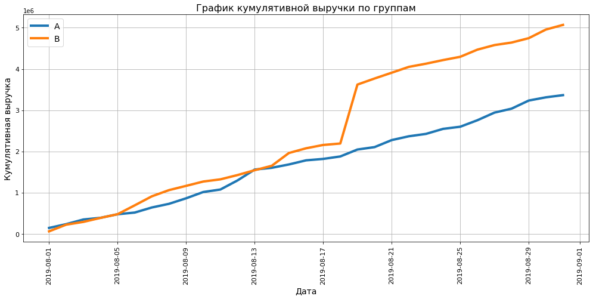

```python
plt.figure(figsize=(17, 7))
plt.plot(cumulative_revenue_a['date'], cumulative_revenue_a['revenue'], label='A', lw=4)
plt.plot(cumulative_revenue_b['date'], cumulative_revenue_b['revenue'], label='B', lw=4)
plt.title('График кумулятивной выручки по группам', fontsize=16)
plt.legend(fontsize=14)
plt.grid()
plt.xticks(rotation=90, fontsize=11)
plt.yticks(fontsize=11)
plt.xlabel('Дата', fontsize=14)
plt.ylabel('Кумулятивная выручка', fontsize=14);
```

#### Вывод по графику кумулятивной выручки по группам:

Выручка почти равномерно увеличивается в течение всего теста для группы А. Однако график выручки группы В резко растет 19 августа. Это может сигнализировать о всплеске числа заказов, либо о появлении очень дорогого заказа в выборке. Аномально большие заказы сильно влияют на результаты. При заключительном анализе их нужно удалить.

### Построим график кумулятивного среднего чека по группам.

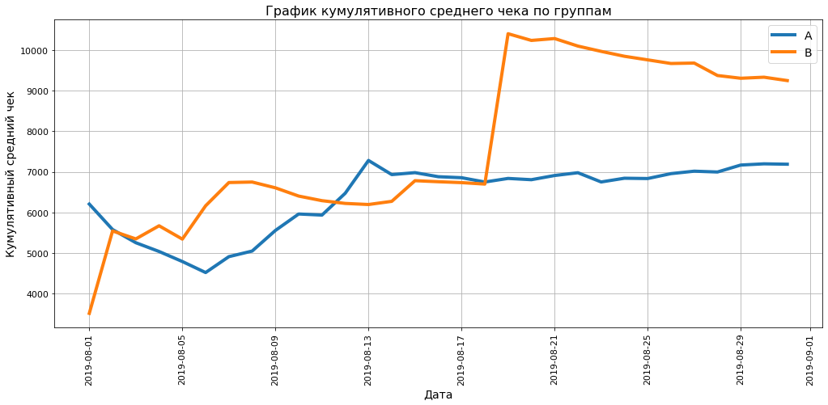

```python
plt.figure(figsize=(17, 7))
plt.plot(cumulative_revenue_a['date'], cumulative_revenue_a['revenue']/cumulative_revenue_a['orders'], label='A', lw=4)
plt.plot(cumulative_revenue_b['date'], cumulative_revenue_b['revenue']/cumulative_revenue_b['orders'], label='B', lw=4)
plt.title('График кумулятивного среднего чека по группам', fontsize=16)
plt.legend(fontsize=14)
plt.grid()
plt.xticks(rotation=90, fontsize=11)
plt.yticks(fontsize=11)
plt.xlabel('Дата', fontsize=14)
plt.ylabel('Кумулятивный средний чек', fontsize=14);
```

#### Вывод по графику кумулятивного среднего чека по группам:

Средний чек становится равномерным ближе к концу теста: установился для группы A и продолжает падать для группы B с 19 августа. Похоже в группу B 19 августа попали крупные заказы (резкий всплеск на графике). Тогда этой группе нужно больше данных, чтобы прийти к реальному среднему чеку и установиться на его уровне. Скорее всего, принимать решение по этой метрике рано. Или требуется дополнительный анализ выбросов, которые так сильно искажают результаты.

### Построим график относительного изменения кумулятивного среднего чека группы B к группе A.

```python
# Соберем данные о кумулятивном количестве заказов и кумулятивной выручке по дням в разных группах в одной таблице.
merged_cumulative_revenue = cumulative_revenue_a.merge(
    cumulative_revenue_b,
    left_on='date',
    right_on='date',
    how='left',
    suffixes=['A', 'B'])
merged_cumulative_revenue.head(10)
```

|  | date | revenueA | ordersA | revenueB | ordersB |
| --- | --- | --- | --- | --- | --- |
| 0 | 2019-08-01 | 142779 | 23 | 59758 | 17 |
| 1 | 2019-08-02 | 234381 | 42 | 221801 | 40 |
| 2 | 2019-08-03 | 346854 | 66 | 288850 | 54 |
| 3 | 2019-08-04 | 388030 | 77 | 385740 | 68 |
| 4 | 2019-08-05 | 474413 | 99 | 475648 | 89 |
| 5 | 2019-08-06 | 515332 | 114 | 690490 | 112 |
| 6 | 2019-08-07 | 638580 | 130 | 909654 | 135 |
| 7 | 2019-08-08 | 727219 | 144 | 1059795 | 157 |
| 8 | 2019-08-09 | 861456 | 155 | 1162961 | 176 |
| 9 | 2019-08-10 | 1013731 | 170 | 1268123 | 198 |

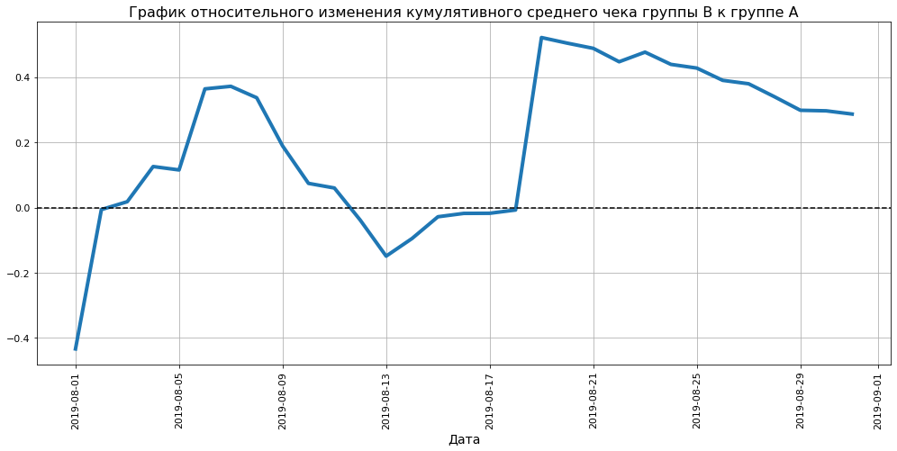

```python
plt.figure(figsize=(17, 7))
plt.plot(
    merged_cumulative_revenue['date'],
    (
        merged_cumulative_revenue['revenueB']
        /merged_cumulative_revenue['ordersB'])
    /(merged_cumulative_revenue['revenueA']
      /merged_cumulative_revenue['ordersA'])-1, lw=4)
plt.title('График относительного изменения кумулятивного среднего чека группы B к группе A', fontsize=16)
plt.grid()
plt.xticks(rotation=90, fontsize=11)
plt.yticks(fontsize=11)
plt.xlabel('Дата', fontsize=14)
plt.axhline(y=0, color='black', linestyle='--') ;
```

#### Вывод по графику относительного изменения кумулятивного среднего чека группы B к группе A:

В нескольких точках график различия между сегментами резко «скачет». Падает с 9 по 13 августа, и резко растет 19 августа. Это говорит о том что в данных присутствуют выбросы.

### Посчитаем среднее количество заказов на посетителя.

```python
cumulative_data['conversion'] = cumulative_data['orders']/cumulative_data['visitors']
```

### Разделим данные по группам

```python
cumulative_data_a = cumulative_data[cumulative_data['group']=='A']
cumulative_data_a.head(10)
```

|  | date | group | orders | buyers | revenue | visitors | conversion |
| --- | --- | --- | --- | --- | --- | --- | --- |
| 0 | 2019-08-01 | A | 23 | 19 | 142779 | 719 | 0.031989 |
| 2 | 2019-08-02 | A | 42 | 36 | 234381 | 1338 | 0.031390 |
| 4 | 2019-08-03 | A | 66 | 60 | 346854 | 1845 | 0.035772 |
| 6 | 2019-08-04 | A | 77 | 71 | 388030 | 2562 | 0.030055 |
| 8 | 2019-08-05 | A | 99 | 92 | 474413 | 3318 | 0.029837 |
| 10 | 2019-08-06 | A | 114 | 104 | 515332 | 3985 | 0.028607 |
| 12 | 2019-08-07 | A | 130 | 120 | 638580 | 4629 | 0.028084 |
| 14 | 2019-08-08 | A | 144 | 133 | 727219 | 5239 | 0.027486 |
| 16 | 2019-08-09 | A | 155 | 143 | 861456 | 5856 | 0.026469 |
| 18 | 2019-08-10 | A | 170 | 158 | 1013731 | 6262 | 0.027148 |

```python
cumulative_data_b = cumulative_data[cumulative_data['group']=='B']
cumulative_data_b.head(10)
```

|  | date | group | orders | buyers | revenue | visitors | conversion |
| --- | --- | --- | --- | --- | --- | --- | --- |
| 1 | 2019-08-01 | B | 17 | 17 | 59758 | 713 | 0.023843 |
| 3 | 2019-08-02 | B | 40 | 39 | 221801 | 1294 | 0.030912 |
| 5 | 2019-08-03 | B | 54 | 53 | 288850 | 1803 | 0.029950 |
| 7 | 2019-08-04 | B | 68 | 66 | 385740 | 2573 | 0.026428 |
| 9 | 2019-08-05 | B | 89 | 87 | 475648 | 3280 | 0.027134 |
| 11 | 2019-08-06 | B | 112 | 109 | 690490 | 3935 | 0.028463 |
| 13 | 2019-08-07 | B | 135 | 132 | 909654 | 4644 | 0.029070 |
| 15 | 2019-08-08 | B | 157 | 154 | 1059795 | 5298 | 0.029634 |
| 17 | 2019-08-09 | B | 176 | 173 | 1162961 | 5908 | 0.029790 |
| 19 | 2019-08-10 | B | 198 | 195 | 1268123 | 6277 | 0.031544 |

### Построим график кумулятивного среднего количества заказов на посетителя по группам.

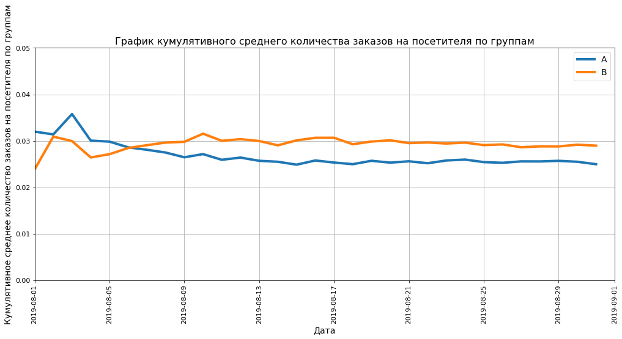

```python
plt.figure(figsize=(17, 7))
plt.plot(cumulative_data_a['date'], cumulative_data_a['conversion'], label='A', lw=4)
plt.plot(cumulative_data_b['date'], cumulative_data_b['conversion'], label='B', lw=4)
plt.title('График кумулятивного среднего количества заказов на посетителя по группам', fontsize=16)
plt.legend(fontsize=14)
plt.grid()
plt.xticks(rotation=90, fontsize=11)
plt.yticks(fontsize=11)
plt.xlabel('Дата', fontsize=14)
plt.ylabel('Кумулятивное среднее количество заказов на посетителя по группам', fontsize=14)
plt.axis([dt.datetime(2019, 8, 1), dt.datetime(2019, 9, 1), 0, 0.05]);
```

#### Вывод по графику кумулятивного среднего количества заказов на посетителя по группам:

В начале теста сегмент A имел большее кумулятивное среднее количество заказов, группы колебались около примерно одинаково до 6 августа, но затем у группы A среднее количество заказов упало и зафиксировалось, а у группы B — наоборот увеличилось, но тоже зафиксировалось примерно после 10 августа, для группы А на значении в 2,6%, а для группы В примерно на 3%.

### Построим график изменения кумулятивного среднего количества заказов на посетителя группы B к группе A.

```python
merged_cumulative_conversions = cumulative_data_a[['date','conversion']].merge(
    cumulative_data_b[['date','conversion']], left_on='date', right_on='date', how='left', suffixes=['A', 'B'])
merged_cumulative_conversions.head(10)
```

|  | date | conversionA | conversionB |
| --- | --- | --- | --- |
| 0 | 2019-08-01 | 0.031989 | 0.023843 |
| 1 | 2019-08-02 | 0.031390 | 0.030912 |
| 2 | 2019-08-03 | 0.035772 | 0.029950 |
| 3 | 2019-08-04 | 0.030055 | 0.026428 |
| 4 | 2019-08-05 | 0.029837 | 0.027134 |
| 5 | 2019-08-06 | 0.028607 | 0.028463 |
| 6 | 2019-08-07 | 0.028084 | 0.029070 |
| 7 | 2019-08-08 | 0.027486 | 0.029634 |
| 8 | 2019-08-09 | 0.026469 | 0.029790 |
| 9 | 2019-08-10 | 0.027148 | 0.031544 |

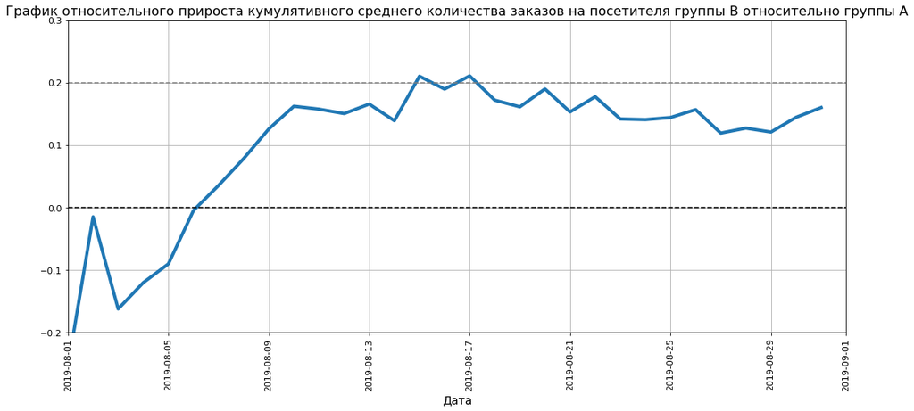

```python
plt.figure(figsize=(17, 7))
plt.plot(merged_cumulative_conversions['date'],
        merged_cumulative_conversions['conversionB']/merged_cumulative_conversions['conversionA']-1, lw=4)
plt.title(
    'График относительного прироста кумулятивного среднего количества заказов на посетителя группы B относительно группы A',
    fontsize=16)
plt.grid()
plt.xticks(rotation=90, fontsize=11)
plt.yticks(fontsize=11)
plt.xlabel('Дата', fontsize=14)
plt.axhline(y=0, color='black', linestyle='--')
plt.axhline(y=0.2, color='grey', linestyle='--')
plt.axis([dt.datetime(2019, 8, 1), dt.datetime(2019, 9, 1), -0.2, 0.3]);
```

#### Вывод по графику относительного прироста кумулятивного среднего количества заказов на посетителя группы B относительно группы A:

С 6 августа группа B лидирует по метрике: растет до 15 августа до значения чуть выше 20%, а потом колеблется на уровне 12-16%, колебания умеренные, уровень можно считать зафиксировавшимся.

### Построим точечную диаграмму числа заказов на одного пользователя.

```python
#таблица с числом уникальных заказов для каждого пользователя
orders_by_users = (
    orders.groupby('visitor_id', as_index=False)
    .agg({'transaction_id': 'nunique'})
)
orders_by_users.columns = ['visitor_id', 'orders']
orders_by_users.head(10)
```

|  | visitor_id | orders |
| --- | --- | --- |
| 0 | 5114589 | 1 |
| 1 | 6958315 | 1 |
| 2 | 11685486 | 1 |
| 3 | 39475350 | 1 |
| 4 | 47206413 | 1 |
| 5 | 48147722 | 1 |
| 6 | 54447517 | 1 |
| 7 | 56960363 | 1 |
| 8 | 66685450 | 1 |
| 9 | 71018815 | 1 |

```python
# серия из чисел от 0 до количества наблюдений в ordersByUsers
x_values = pd.Series(range(0, len(orders_by_users)))
```

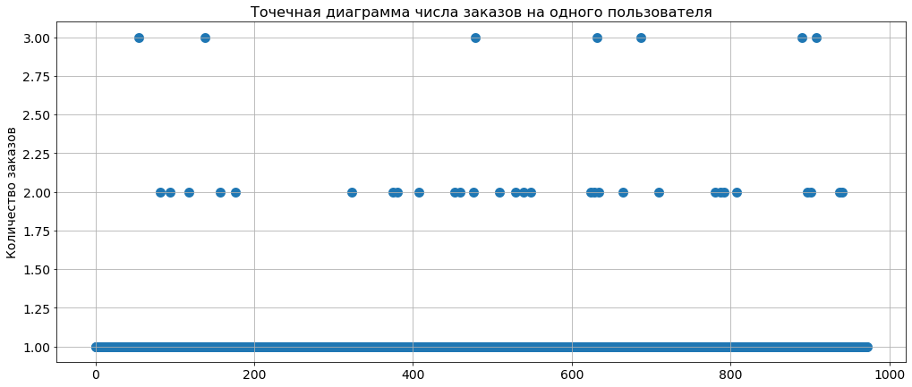

```python
plt.figure(figsize=(17, 7))
plt.scatter(x_values, orders_by_users['orders'],lw=5)
plt.title('Точечная диаграмма числа заказов на одного пользователя', fontsize=16)
plt.grid()
plt.xticks(fontsize=14)
plt.yticks(fontsize=14)
plt.ylabel('Количество заказов', fontsize=14);
```

### Посчитаем выборочные перцентили количества заказов на одного пользователя.

```python
np.percentile(orders_by_users['orders'], [90, 95, 99])
```

```
array([1., 1., 2.])
```

#### Вывод по точечной диаграмме числа заказов на одного пользователя.

Пользователей, заказавших более двух раз, совсем мало Скорее всего ользователей с числом заказов больше 2 можно считать аномальными. Проверили это предположение, посчитав выборочные перцентили.

Не более 1% пользователей совершали больше двух заказов.

За границу для определения аномальных пользователей возьмем 2 заказа. При заключительном анализе не будем учитывать пользователей, которые сделали 3 заказа.

### Построим точечную диаграмму стоимости заказов.

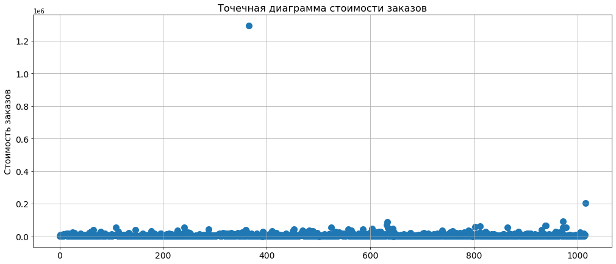

```python
x_values = pd.Series(range(0, len(orders['revenue'])))

plt.figure(figsize=(17, 7))
plt.scatter(x_values, orders['revenue'], lw=5)
plt.title('Точечная диаграмма стоимости заказов', fontsize=16)
plt.grid()
plt.xticks(fontsize=14)
plt.yticks(fontsize=14)
plt.ylabel('Стоимость заказов', fontsize=14);
```

На графике есть один выброс, примерно на значении в 1.300.000 и один на значении в 200.000, из-за них сложно судить о распределении стоимости заказов по графику. Установим врехнюю границу стоимости заказа на 100.000.

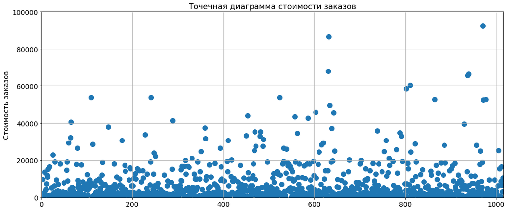

```python
plt.figure(figsize=(17, 7))
plt.scatter(x_values, orders['revenue'], lw=5)
plt.title('Точечная диаграмма стоимости заказов', fontsize=16)
plt.grid()
plt.xticks(fontsize=14)
plt.yticks(fontsize=14)
plt.ylabel('Стоимость заказов', fontsize=14)
plt.axis([0, len(orders['revenue']), 0, 100000]);
```

### Посчитаем выборочные перцентили стоимости заказов.

```python
np.percentile(orders['revenue'], [90, 95, 99])
```

```
array([17990., 26785., 53904.])
```

#### Вывод по точечной диаграмме стоимости заказов:

Стоимость большинства заказов не превышает 20.000, заказов дороже 50.000 очень мало, есть выбросы на 200.000 и на 1.300.000

Не более 5% заказов стоят дороже 27.000. И не более 1% заказов — больше 54.000.

За границу для определения аномальных заказов возьмем 50.000. При заключительном анализе не будем учитывать заказы, стоимость которых превышает 50.000.

### Посчитаем статистическую значимость различий в среднем числе заказов на посетителя между группами без удаления аномальных пользователей.

Сформулируем гипотезы:

Н0: "Статистически значимых различий в среднем числе заказов между группами нет"

Н1: "Статистически значимые различия в среднем числе заказов между группами есть"

```python
orders_by_users_a = orders[orders['group'] == 'A'].groupby('visitor_id', as_index=False).agg({'transaction_id': 'nunique'})
orders_by_users_a.columns = ['visitor_id', 'orders']

visitors_a_daily = visitors[visitors['group'] == 'A'][['date', 'visitors']]
visitors_a_daily.columns = ['date', 'visitors_per_date_a']

sample_a = pd.concat(
    [orders_by_users_a['orders'],
     pd.Series(
         0,
         index=np.arange(
             visitors_a_daily['visitors_per_date_a'].sum() - len(orders_by_users_a['orders'])),
         name='orders')],
    axis=0)
```

```python
orders_by_users_b = orders[orders['group'] == 'B'].groupby('visitor_id', as_index=False).agg({'transaction_id': 'nunique'})
orders_by_users_b.columns = ['visitor_id', 'orders']

visitors_b_daily = visitors[visitors['group'] == 'B'][['date', 'visitors']]
visitors_b_daily.columns = ['date', 'visitors_per_date_b']

sample_b = pd.concat(
    [orders_by_users_b['orders'],
     pd.Series(
         0,
         index=np.arange(
             visitors_b_daily['visitors_per_date_b'].sum() - len(orders_by_users_b['orders'])),
         name='orders')],
    axis=0)
```

```python
print('p_value:', "{0:.3f}".format(st.mannwhitneyu(sample_a, sample_b)[1]))

print('Относительная разница между группами:',"{0:.3f}".format(sample_b.mean() / sample_a.mean() - 1))
```

```
p_value: 0.011
Относительная разница между группами: 0.160
```

#### Вывод:

Первое число — p-value = 0.011 меньше 0.05. Значит, нулевую гипотезу о том, что статистически значимых различий в среднем числе заказов между группами нет, отвергаем. Относительный выигрыш группы B равен 16% — второе число в выводе.

### Посчитаем статистическую значимость различия в среднем чеке заказа между группами без удаления аномальных пользователей.

Сформулируем гипотезы:

Н0: "Статистически значимых различий в среднем чеке между группами нет"

Н1: "Статистически значимые различия в среднем чеке между группами есть"

```python
print('p_value:',
    '{0:.3f}'.
    format(
        st.
        mannwhitneyu(
            orders[orders['group']=='A']['revenue'], orders[orders['group']=='B']['revenue'])[1]))

print('Относительная разница между группами:',
    '{0:.3f}'.
    format(
        orders[orders['group']=='B']['revenue'].mean()
        /orders[orders['group']=='A']['revenue'].mean()-1))
```

```
p_value: 0.829
Относительная разница между группами: 0.287
```

#### Вывод:

P-value значительно больше 0.05. Значит, причин отвергать нулевую гипотезу и считать, что в среднем чеке есть различия, нет. Однако средний чек группы B на 28.7% выше среднего чека группы A.

### Посчитаем статистическую значимость различий в среднем количестве заказов на посетителя между группами по «очищенным» данным.

```python
# соберем в таблице пользователей, сделавших аномально большое количество заказов
users_with_many_orders = pd.concat(
    [
        orders_by_users_a[orders_by_users_a['orders'] > 2]['visitor_id'],
        orders_by_users_b[orders_by_users_b['orders'] > 2]['visitor_id'],
    ],
    axis=0,
)
# соберем в таблице пользователей, сделавших аномально дорогие заказы
users_with_expensive_orders = orders[orders['revenue'] > 50000]['visitor_id']
# объединим аномальных пользователей в одной таблице
abnormal_users = (
    pd.concat([users_with_many_orders, users_with_expensive_orders], axis=0)
    .drop_duplicates()
    .sort_values()
)
print(abnormal_users.head(5))
print()
print('Количество аномальных польователей:', abnormal_users.shape[0])
```

```
1099    148427295
33      249864742
58      611059232
1137    759473111
949     887908475
Name: visitor_id, dtype: int64

Количество аномальных польователей: 22
```

Всего 22 аномальных пользователя, в заключительный анализ не будем включать их ID.

```python
sample_a_filtered = pd.concat(
    [
        orders_by_users_a[
            np.logical_not(orders_by_users_a['visitor_id'].isin(abnormal_users))
        ]['orders'],
        pd.Series(
            0,
            index=np.arange(
                visitors_a_daily['visitors_per_date_a'].sum() - len(orders_by_users_a['orders'])
            ),
            name='orders',
        ),
    ],
    axis=0,
)
```

```python
sample_b_filtered = pd.concat(
    [
        orders_by_users_b[
            np.logical_not(orders_by_users_b['visitor_id'].isin(abnormal_users))
        ]['orders'],
        pd.Series(
            0,
            index=np.arange(
                visitors_b_daily['visitors_per_date_b'].sum() - len(orders_by_users_b['orders'])
            ),
            name='orders',
        ),
    ],
    axis=0,
)
```

Сформулируем гипотезы:

Н0: "Статистически значимых различий в среднем числе заказов между группами нет"

Н1: "Статистически значимые различия в среднем числе заказов между группами есть"

```python
print('p_value:',"{0:.3f}".format(st.mannwhitneyu(sample_a_filtered, sample_b_filtered)[1]))

print('Относительная разница между группами:',"{0:.3f}".format(sample_b_filtered.mean() / sample_a_filtered.mean() - 1))
```

```
p_value: 0.006
Относительная разница между группами: 0.198
```

#### Вывод:

Первое число — p-value = 0.006 всё еще меньше 0.05. Значит, нулевую гипотезу о том, что статистически значимых различий в среднем числе заказов между группами нет, отвергаем. Относительный выигрыш группы B по очищенным данным равен 19,8%

### Посчитаем статистическую значимость различий в среднем чеке заказа между группами по «очищенным» данным.

Сформулируем гипотезы:

Н0: "Статистически значимых различий в среднем чеке между группами нет"

Н1: "Статистически значимые различия в среднем чеке между группами есть"

```python
print('p_value:',
    '{0:.3f}'.format(
        st.mannwhitneyu(
            orders[
                np.logical_and(
                    orders['group'] == 'A',
                    np.logical_not(orders['visitor_id'].isin(abnormal_users)),
                )
            ]['revenue'],
            orders[
                np.logical_and(
                    orders['group'] == 'B',
                    np.logical_not(orders['visitor_id'].isin(abnormal_users)),
                )
            ]['revenue'],
        )[1]
    )
)

print('Относительная разница между группами:',
    "{0:.3f}".format(
        orders[
            np.logical_and(
                orders['group'] == 'B',
                np.logical_not(orders['visitor_id'].isin(abnormal_users)),
            )
        ]['revenue'].mean()
        / orders[
            np.logical_and(
                orders['group'] == 'A',
                np.logical_not(orders['visitor_id'].isin(abnormal_users)),
            )
        ]['revenue'].mean()
        - 1
    )
)
```

```
p_value: 0.939
Относительная разница между группами: 0.011
```

#### Вывод:

P-value значительно больше 0.05. Значит, причин отвергать нулевую гипотезу и считать, что в среднем чеке есть различия, нет. По очищенным данным средний чек группы B на 1,1% больше среднего чека группы А. Аномально дорогие заказы, попав в группу В сильно искажали разницу в среднем чеке.

### Сравним графики до и после удаления аномальных значений чтобы оценить влияние аномалий.

```python
orders_filtered = orders.loc[~orders['visitor_id'].isin(abnormal_users)]
```

```python
orders_aggregated_filtered = (
dates_groups.apply(
    lambda x:
    orders_filtered[np.logical_and(
        orders_filtered['date'] <= x['date'],
        orders_filtered['group'] == x['group'])]
    .agg({'date' : 'max',
          'group' : 'max',
          'transaction_id' : 'nunique',
          'visitor_id' : 'nunique',
          'revenue' : 'sum'}),
    axis=1).sort_values(
    by=['date','group']))

visitors_aggregated = (
    dates_groups.apply(
        lambda x:
        visitors[np.logical_and(
            visitors['date'] <= x['date'],
            visitors['group'] == x['group'])]
        .agg({'date' : 'max',
              'group' : 'max',
              'visitors' : 'sum'}),
        axis=1).sort_values(
        by=['date','group']))

cumulative_data_filtered = orders_aggregated_filtered.merge(
    visitors_aggregated,
    left_on=['date', 'group'],
    right_on=['date', 'group'])
cumulative_data_filtered.columns = ['date', 'group', 'orders', 'buyers', 'revenue', 'visitors']

cumulative_revenue_a_filtered = cumulative_data_filtered[cumulative_data_filtered['group']=='A'][['date','revenue', 'orders']]
cumulative_revenue_b_filtered = cumulative_data_filtered[cumulative_data_filtered['group']=='B'][['date','revenue', 'orders']]
```

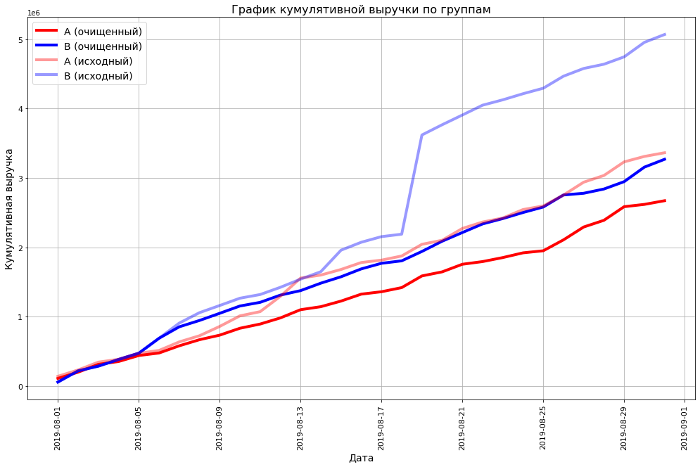

```python
plt.figure(figsize=(17, 10))

plt.plot(cumulative_revenue_a_filtered['date'],
         cumulative_revenue_a_filtered['revenue'],
         label='A (очищенный)',
         lw=4,
         color='red')
plt.plot(cumulative_revenue_b_filtered['date'],
         cumulative_revenue_b_filtered['revenue'],
         label='B (очищенный)',
         lw=4,
         color='blue')
plt.plot(cumulative_revenue_a['date'],
         cumulative_revenue_a['revenue'],
         label='A (исходный)',
         lw=4,
         color='red',
         alpha=0.4)
plt.plot(cumulative_revenue_b['date'],
         cumulative_revenue_b['revenue'],
         label='B (исходный)',
         lw=4,
         color='blue',
         alpha=0.4)

plt.title('График кумулятивной выручки по группам', fontsize=16)
plt.legend(fontsize=14)
plt.grid()
plt.xticks(rotation=90, fontsize=11)
plt.yticks(fontsize=11)
plt.xlabel('Дата', fontsize=14)
plt.ylabel('Кумулятивная выручка', fontsize=14);
```

Очищенные данные по группе "А" показывают более седленный рост, чем сырые. В очищенных данных по группе "В" отсутствуют скачки, выручка растет равномерно и показывает лучшие результаты по сравнению с группой "А".

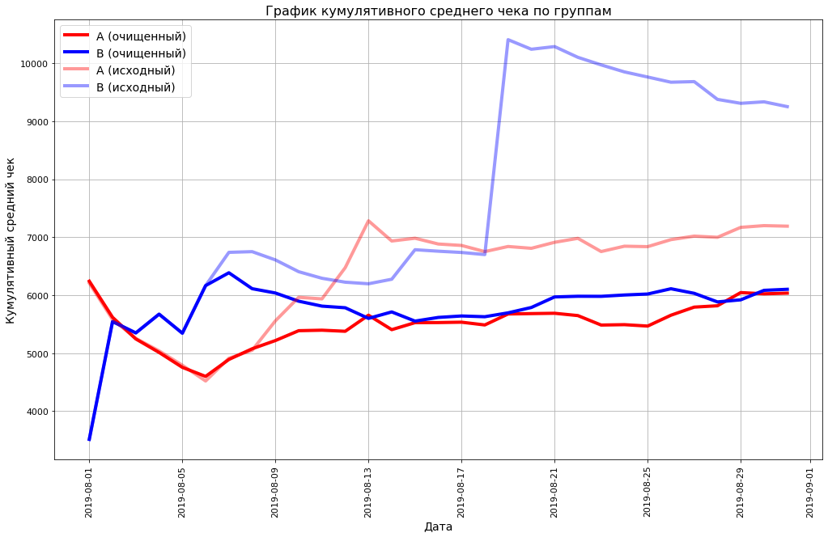

```python
plt.figure(figsize=(17, 10))

plt.plot(cumulative_revenue_a_filtered['date'],
         cumulative_revenue_a_filtered['revenue']/cumulative_revenue_a_filtered['orders'],
         label='A (очищенный)',
         lw=4,
        color='red')
plt.plot(cumulative_revenue_b_filtered['date'],
         cumulative_revenue_b_filtered['revenue']/cumulative_revenue_b_filtered['orders'],
         label='B (очищенный)',
         lw=4,
         color='blue')
plt.plot(cumulative_revenue_a['date'],
         cumulative_revenue_a['revenue']/cumulative_revenue_a['orders'],
         label='A (исходный)',
         lw=4,
         color='red',
         alpha=0.4)
plt.plot(cumulative_revenue_b['date'],
         cumulative_revenue_b['revenue']/cumulative_revenue_b['orders'],
         label='B (исходный)',
         lw=4,
         color='blue',
         alpha=0.4)

plt.title('График кумулятивного среднего чека по группам', fontsize=16)
plt.legend(fontsize=14)
plt.grid()
plt.xticks(rotation=90, fontsize=11)
plt.yticks(fontsize=11)
plt.xlabel('Дата', fontsize=14)
plt.ylabel('Кумулятивный средний чек', fontsize=14);
```

Графики по очищенным результатам среднего чека находятся примерно на одном уровне для обеих групп.

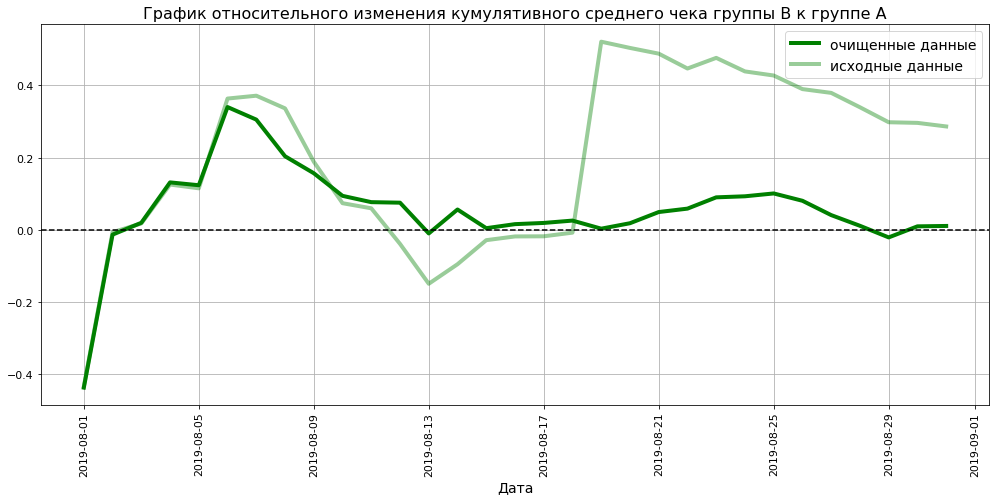

```python
merged_cumulative_revenue_filtered = cumulative_revenue_a_filtered.merge(
    cumulative_revenue_b_filtered,
    left_on='date',
    right_on='date',
    how='left',
    suffixes=['A', 'B'])

plt.figure(figsize=(17, 7))

plt.plot(
    merged_cumulative_revenue_filtered['date'],
    (
        merged_cumulative_revenue_filtered['revenueB']
        /merged_cumulative_revenue_filtered['ordersB'])
    /(merged_cumulative_revenue_filtered['revenueA']
      /merged_cumulative_revenue_filtered['ordersA'])-1,
    lw=4,
    color='green',
    label='очищенные данные')

plt.plot(
    merged_cumulative_revenue['date'],
    (
        merged_cumulative_revenue['revenueB']
        /merged_cumulative_revenue['ordersB'])
    /(merged_cumulative_revenue['revenueA']
      /merged_cumulative_revenue['ordersA'])-1,
    lw=4,
    color='green',
    alpha=0.4,
    label='исходные данные')

plt.title('График относительного изменения кумулятивного среднего чека группы B к группе A', fontsize=16)
plt.grid()
plt.legend(fontsize=14)
plt.xticks(rotation=90, fontsize=11)
plt.yticks(fontsize=11)
plt.xlabel('Дата', fontsize=14)
plt.axhline(y=0, color='black', linestyle='--') ;
```

График относительного изменения кумулятивного среднего чека группы B к группе A по очищенным данным показывал хороший результат с 5 по 10 августа, а к концу исследования разницы в средних чеках практически не наблюдалось.

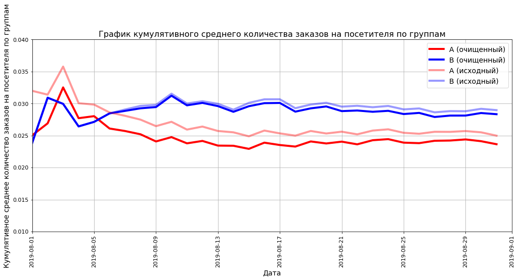

```python
cumulative_data_filtered['conversion'] = cumulative_data_filtered['orders']/cumulative_data_filtered['visitors']

cumulative_data_a_filtered = cumulative_data_filtered[cumulative_data_filtered['group']=='A']
cumulative_data_b_filtered = cumulative_data_filtered[cumulative_data_filtered['group']=='B']

plt.figure(figsize=(17, 7))

plt.plot(cumulative_data_a_filtered['date'],
         cumulative_data_a_filtered['conversion'],
         label='A (очищенный)',
         lw=4,
         color='red')
plt.plot(cumulative_data_b_filtered['date'],
         cumulative_data_b_filtered['conversion'],
         label='B (очищенный)',
         lw=4,
         color='blue')
plt.plot(cumulative_data_a['date'],
         cumulative_data_a['conversion'],
         label='A (исходный)',
         lw=4,
         color='red',
         alpha=0.4)
plt.plot(cumulative_data_b['date'],
         cumulative_data_b['conversion'],
         label='B (исходный)',
         lw=4,
         color='blue',
         alpha=0.4)

plt.title('График кумулятивного среднего количества заказов на посетителя по группам', fontsize=16)
plt.legend(fontsize=14)
plt.grid()
plt.xticks(rotation=90, fontsize=11)
plt.yticks(fontsize=11)
plt.xlabel('Дата', fontsize=14)
plt.ylabel('Кумулятивное среднее количество заказов на посетителя по группам', fontsize=14)
plt.axis([dt.datetime(2019, 8, 1), dt.datetime(2019, 9, 1), 0.01, 0.04]);
```

График кумулятивного среднего количества заказов на посетителя по группам практически не изменился для обеих групп.

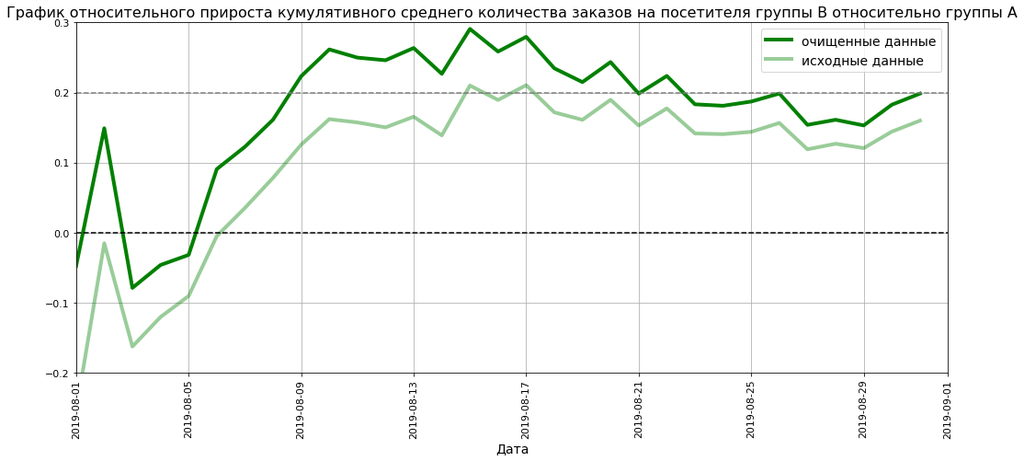

```python
merged_cumulative_conversions_filtered = cumulative_data_a_filtered[['date','conversion']].merge(
    cumulative_data_b_filtered[['date','conversion']], left_on='date', right_on='date', how='left', suffixes=['A', 'B'])

plt.figure(figsize=(17, 7))

plt.plot(merged_cumulative_conversions_filtered['date'],
         merged_cumulative_conversions_filtered['conversionB']/merged_cumulative_conversions_filtered['conversionA']-1,
         lw=4,
         color='green',
         label='очищенные данные')
plt.plot(merged_cumulative_conversions['date'],
         merged_cumulative_conversions['conversionB']/merged_cumulative_conversions['conversionA']-1,
         lw=4,
         color='green',
         alpha=0.4,
         label='исходные данные')

plt.title(
    'График относительного прироста кумулятивного среднего количества заказов на посетителя группы B относительно группы A',
    fontsize=16)
plt.grid()
plt.legend(fontsize=14)
plt.xticks(rotation=90, fontsize=11)
plt.yticks(fontsize=11)
plt.xlabel('Дата', fontsize=14)
plt.axhline(y=0, color='black', linestyle='--')
plt.axhline(y=0.2, color='grey', linestyle='--')
plt.axis([dt.datetime(2019, 8, 1), dt.datetime(2019, 9, 1), -0.2, 0.3]);
```

График относительного прироста кумулятивного среднего количества заказов на посетителя группы B относительно группы A по очищенным данным показал лучшие результаты по сравнению с графиком по сырым данным.

### Обобщим результаты работы.

1. При предварительном анализе данных было выявлено, что не для всех пользователей принадлежность к одной группе сохранялась на протяжении всего теста. Из-за этого невозможно выяснить повлияли ли на поведение этих пользователей тестируемые изменения, поэтому было принято решение, удалить данные таких пользователей. Удаление более 10% заказов снизило конверсию обеих групп, но так как целью исследования является сравнение поведения пользователей в тестируемых группах, а не точное определение бизнес-показателей, такой подход является оптимальным.
1. Вероятность попадания в группу "В" на 8% выше вероятности попадания в группу "А", эту проблему необходимо было устранить проведением А/А теста, о начала проведения А/В теста.
2. Выручка почти равномерно увеличивается в течение всего теста для группы А. Однако график выручки группы В резко растет 19 августа из-за аномально дорогого заказа.

3.1. После очистки данных от аномалий оба графике показывают стабильный рост выручки на протяжении всего периода исследования, причем выручка группы "В" показывает лучший результат по сравнению с группой "А".

1. Средний чек становится равномерным ближе к концу теста: установился для группы "A" и продолжает падать для группы "B" с 19 августа. В группу "B" 19 августа попал аномально крупный заказ, на графике это отразилось резким всплеском.

4.1. После очистки данных от аномалий средний чек стал почти одинаковым для обеих групп, и установился на отметке около 6.000 к конце теста, на протяжении почти всего периода тестирования средний чек группы "В" был немного выше среднего чека группы "А"

1. В нескольких точках график различия между тестируемыми группами по среднему чеку резко «скачет». Падает с 9 по 13 августа, и резко растет 19 августа. Это происходит из-за выбросов.

5.1. После удаления выбросов на графике относительного изменения кумулятивного среднего чека группы B к группе A остался один пик на отметке примерно в 0.35 в пользу группы "В" 6 августа, но после 10 августа выигрыш группы "В" не превышал 10%, а концу теста практически сравнялся с нулем.

1. В начале теста сегмент A имел большее кумулятивное среднее количество заказов, группы колебались около примерно одинаково до 5 августа, но затем у группы A среднее количество заказов упало и зафиксировалось, а у группы B — наоборот увеличилось, но тоже зафиксировалось примерно после 10 августа, для группы А на значении в 2,5%, а для группы В примерно на 2,8%.

1. С 6 августа группа B лидирует по относительному приросту кумулятивного среднего количества заказов: растет до 15 августа до значения чуть выше 20%, но потом снижается до 27 августа до 10%.

7.1. Для очищенных данных график относительного прироста кумулятивного среднего числа заказов выглядит так же, но располагается выше, доходит до 30% 15 августа, и дальше снижается до 15-20%.

8.1. Пользователей, заказавших более двух раз, совсем мало, их можно считать аномальными, так как не более 1% пользователей совершали больше двух заказов. При заключительном анализе не будем учитывать пользователей у которых более 2 заказов.

8.2. Стоимость большинства заказов не превышает 50.000, есть выбросы на 200.000 и на 1.300.000, не более 1% заказов стоят дороже 54.000. За границу для определения аномальных заказов возьмем 50.000. При заключительном анализе не будем учитывать заказы, стоимость которых превышает этой суммы.

9.1. Сформулируем гипотезы для среднего количества заказов. Нулевая: различий в среднем количестве заказов между группами нет. Альтернативная: различия в среднем между группами есть.

Р-value = 0.011 меньше 0.05. Значит, нулевую гипотезу отвергаем, различия в среднем количестве заказов между группами есть. Относительный выигрыш группы B равен 16%.

После "очистки" данных от аномалий p-value = 0.006 всё еще меньше 0.05. Значит, нулевую гипотезу отвергаем. Относительный выигрыш группы B по очищенным данным равен 19,8%

9.2. Сформулируем гипотезы для среднего чека. Нулевая гипотеза: различий в среднем чеке между группами нет. Альтернативная гипотеза: различия в среднем чеке между группами есть.

P-value значительно больше 0.05. Значит, нет причин отвергать нулевую гипотезу. Однако средний чек группы B на 28,7% выше среднего чека группы A, на результат сильно влияют выбросы.

После "очистки" данных от аномалий р-value значительно больше 0.05. Значит нулевую гипотезу не отвергаем. По очищенным данным средний чек группы B на 1,1% больше среднего чека группы А. Аномально дорогие заказы, попав в группу В сильно искажали разницу в среднем чеке.

1. На основе результатов А/В-теста можно сделать вывод о победе группы В по среднему числу заказов на пользователя и остановить тест, по среднему чеку различий в двух группах не наблюдается.